# siRNA discovery for SARS-CoV-2

Denis O’Meally

Center for Gene Therapy, Beckman Research Institute of the City of Hope

30 July, 2020

```r
library(tidyr)
library(knitr)
library(rmarkdown)
library(rtracklayer)
library(DT)
library(ggplot2)
library(formattable)
library(broom)
library(xlsx)
##################################################################
### Load data from preparitory scripts
load("SARS12.Rdata")
load("SARS2_intervals.RData")
### Load SARS2 annotation        # Downloaded manually from NCBI
#gff_path <- ("../data/GCF_009858895.2_ASM985889v3_genomic.gff")
SARS2_gff_path <- ("../data/NC_045512v2.gff")
SARS2.gff      <- import.gff3(SARS2_gff_path)

### Set report options here
options(scipen=999)

##################################################################
# NOTE: Search for text within <div></div> braces to update text specific to this analysis
##################################################################
```

# 1 Background

## Datasets

This analysis draws on three studies that characterise the 29,903bp RNA genome of SARS-CoV-2 for structural features (Andrews et al. 2020; Rangan, Zheludev, and Das 2020), sequence conservation (Rangan, Zheludev, and Das 2020) and RNA modifications (Kim et al. 2020). We use these data to prioitize ~9500 candidate siRNAs generated by the OligoWalk pipeline (Mathews 2010), DSIR (Vert et al. 2006; Filhol 2012) and 36 candidate siRNAs designed by Tristan Scott. In addition, 163 experimentally validated SARS-CoV-1 siRNAs are assessed for homology with SARS-CoV-2.

## Genome browser

For Visualisation outside this report, visit the UCSC SARS-CoV-2 Genome Browser (Fernandes et al. 2020). Data from this analysis can be visualised on more than **[20 additional tracks](http://genome.ucsc.edu/cgi-bin/hgTracks?hubUrl=https://drejom.github.io/trackHubs/hubs.txt&db=wuhCor1)** served from a custom trackHub.

## Approach

OligoWalk uses a machine learning algorithm to assess the effect of target and guide-strand self-structures and 24 sequence features known to impact siRNA efficacy in shorlisting candidates. DSIR uses a simple linear model that considers only sequence features of candidates. Both OligoWalk and DSIR assess the entire SARS2 genome in sliding 21 bp windows for candidate siRNAs, so in regions of the genome where structural or sequence features are suboptimal, no candidates are reported. For each algorithm, we produce a list of the top 10 candidates and the bottom 10 candidates, as ranked by efficacy.

For the combined analysis, we restrict the candidates to those that fall in windows defined by the lack of secondary structure (viz. Rangan, Andrews), sequence conservation (in GISAID, in SARS-CoV-1, in bat coronaviruses and in vertebrate coronaviruses), off-target effects (seed sequence frequency in human transcripts) and finally consider endogenous mRNA modifications of viral genes.

Excel sheets and figures from this report can be found in the results folder.

# 2 Candidate siRNAs

```r
# Set up Gvis tracks
library(Gviz)

### Allow non-standard USCS chr names
options(ucscChromosomeNames=FALSE)

SARS2_gtrack    <- GenomeAxisTrack()
SARS2_annoTrack <- GeneRegionTrack(SARS2.gff,
                           chromosome = "NC_045512v2" ,
                           name = "NCBI Annotation",
                           shape="arrow",
                           showId=TRUE,
                           geneSymbols=TRUE,
                           transcriptAnnotation="gene",
                           collapseTranscripts="longest")
OW.gr            <- makeGRangesFromDataFrame(SARS2.data[!is.na(SARS2.data$OW.prob),], keep.extra.columns=TRUE)
DSIR.gr          <- makeGRangesFromDataFrame(SARS2.data[!is.na(SARS2.data$DSIR.score),], keep.extra.columns=TRUE)
COH.gr           <- makeGRangesFromDataFrame(SARS2.data[!is.na(SARS2.data$COH.name),], keep.extra.columns=TRUE)
VIRsiDB.gr       <- makeGRangesFromDataFrame(SARS2.data[!is.na(SARS2.data$VIRsiRNAid),], keep.extra.columns=TRUE)
```

## 2.1 OligoWalk Candidates

```r
SARS2.OW <- SARS2.data[!is.na(SARS2.data$OW.prob), grepl("chr|start|end|strand|name|refSeq|OW", names(SARS2.data)) ]
```

OligoWalk considers the equilibrium of the siRNA guide strand hybridization with the target mRNA. The software calculates thermodynamic features of sense-antisense hybridization and predicts the free energy changes of oligonucleotides binding to a target RNA. The [SVM](https://en.wikipedia.org/wiki/Support_vector_machine) uses this information in addition to sequence-based features to propose efficient siRNAs targeting a given mRNA sequence. Analysis of SARS-CoV-2 gRNA resulted in **8530** candidates.

- [Matthews 2010](https://link.springer.com/protocol/10.1007%2F978-1-60761-657-3_8)

### 2.1.1 Top and bottom 10

Top and bottom 10 candidates, ranked by OligoWalk’s *probability of efficacy score* (`OW.prob`). The top 10 scores are indicated in green, the bottom 10 in red.

```r
SARS2.OW <- SARS2.OW[order(SARS2.OW$OW.prob, decreasing = TRUE),]

SARS2.OW.top10 <- head(n=10,SARS2.OW[ , !grepl("SARS1|prefilter|COH", names(SARS2.OW)) ])
SARS2.OW.top10$selection <- "TOP_10"
SARS2.OW.top10.gr <- makeGRangesFromDataFrame(SARS2.OW.top10, keep.extra.columns=TRUE)


SARS2.OW.bottom10 <- tail(n=10,SARS2.OW[ , !grepl("SARS1|prefilter|COH", names(SARS2.OW)) ])
SARS2.OW.bottom10$selection <- "BOTTOM_10"
SARS2.OW.bottom10.gr <- makeGRangesFromDataFrame(SARS2.OW.bottom10, keep.extra.columns=TRUE)

# make a table of both the top 10 abd bottom 10
SARS2.OW.selection<-rbind(SARS2.OW.top10,SARS2.OW.bottom10)
rownames(SARS2.OW.selection)<-NULL

formattable(SARS2.OW.selection,
            align = c(rep("l", 3, ), "c", "l" ,rep("c", NCOL(SARS2.OW.selection) - 1)),
            list(name = FALSE,
                 selection = FALSE,
                 OW.prob = color_tile('firebrick2', 'seagreen4'),
                 refSeq = formatter("span", style=style("font-family" = "courier")),
                 strand = formatter("span", style=style("font-family" = "courier"))))
```

| chr | start | end | strand | refSeq | OW.prob | OW.overall | OW.duplex | OW.Tm.dup | OW.break.targ | OW.intraoligo | OW.interoligo | OW.end_diff |
| --- | --- | --- | --- | --- | --- | --- | --- | --- | --- | --- | --- | --- |
| NC_045512v2 | 15251 | 15271 | + | CTGTTTATAGTGATGTAGAAA | 0.962588 | -22.2 | -29.1 | 76.4 | -5.3 | 0.0 | -11.4 | 1.60 |
| NC_045512v2 | 15959 | 15979 | + | CCGGCTGTTTTGTAGATGATA | 0.959761 | -24.2 | -35.0 | 84.3 | -8.7 | 0.0 | -12.4 | 1.93 |
| NC_045512v2 | 7005 | 7025 | + | CCGCTGCTTTAGGTGTTTTAA | 0.957904 | -25.1 | -34.1 | 85.2 | -7.0 | -0.1 | -12.1 | 2.33 |
| NC_045512v2 | 16705 | 16725 | + | GTGCTGTCTGACAGAGAATTA | 0.956633 | -24.6 | -36.0 | 84.5 | -6.3 | -1.9 | -18.4 | 1.36 |
| NC_045512v2 | 15416 | 15436 | + | GTGCTCAAGTATTGAGTGAAA | 0.954146 | -20.8 | -33.3 | 81.7 | -8.9 | -3.4 | -14.5 | 1.76 |
| NC_045512v2 | 15191 | 15211 | + | GAGCTACTGTAGTAATTGGAA | 0.951972 | -25.9 | -33.8 | 83.3 | -5.2 | -0.8 | -13.6 | 1.87 |
| NC_045512v2 | 9012 | 9032 | + | CTGCTGAATGTACAATTTTTA | 0.951923 | -20.1 | -28.4 | 75.7 | -5.8 | -0.8 | -13.2 | 1.20 |
| NC_045512v2 | 24474 | 24494 | + | GTGCAATTTCAAGTGTTTTAA | 0.951292 | -19.5 | -27.9 | 75.3 | -6.7 | -0.2 | -11.6 | 1.76 |
| NC_045512v2 | 7515 | 7535 | + | GAGCAACAAGAGTCGAATGTA | 0.951243 | -25.6 | -35.1 | 83.6 | -6.8 | -2.6 | -12.5 | 1.47 |
| NC_045512v2 | 21927 | 21947 | + | ACGCTACTAATGTTGTTATTA | 0.949867 | -20.8 | -28.9 | 77.9 | -6.3 | -0.2 | -11.7 | 0.46 |
| NC_045512v2 | 11441 | 11461 | + | GCTTTAGATCAAGCCATTTCC | 0.138181 | -21.6 | -35.0 | 83.2 | -10.3 | -2.9 | -13.7 | 0.16 |
| NC_045512v2 | 24257 | 24277 | + | GCTATGCAAATGGCTTATAGG | 0.138079 | -24.6 | -35.2 | 84.4 | -7.9 | -1.5 | -13.4 | 0.16 |
| NC_045512v2 | 3824 | 3844 | + | GTTTCAAGCTTTTTGGAAATG | 0.138075 | -13.6 | -29.3 | 76.3 | -13.0 | -0.9 | -13.6 | 0.13 |
| NC_045512v2 | 28987 | 29007 | + | CCAACAACAACAAGGCCAAAC | 0.135714 | -24.0 | -36.0 | 86.2 | -8.5 | -0.5 | -15.1 | 0.57 |
| NC_045512v2 | 29573 | 29593 | + | GTTTTCGCTTTTCCGTTTACG | 0.135417 | -24.2 | -31.8 | 80.5 | -5.0 | -1.2 | -13.4 | 0.33 |
| NC_045512v2 | 11292 | 11312 | + | GTTTTAAGCTAAAAGACTGTG | 0.123645 | -11.2 | -29.8 | 78.0 | -16.5 | -0.6 | -12.4 | 0.13 |
| NC_045512v2 | 22572 | 22592 | + | CTTTTGGTGAAGTTTTTAACG | 0.119608 | -17.1 | -28.4 | 76.0 | -9.7 | -0.2 | -11.4 | 0.17 |
| NC_045512v2 | 28638 | 28658 | + | CCTATGGTGCTAACAAAGACG | 0.118357 | -22.2 | -36.3 | 86.0 | -11.1 | -0.9 | -14.2 | 0.90 |
| NC_045512v2 | 26242 | 26262 | + | CTTATGTACTCATTCGTTTCG | 0.115090 | -15.6 | -31.3 | 78.3 | -13.9 | -0.6 | -11.7 | 0.17 |
| NC_045512v2 | 27047 | 27067 | + | GCTTTCTTATTACAAATTGGG | 0.078427 | -19.4 | -30.0 | 77.7 | -9.2 | -0.2 | -10.8 | 0.16 |

```r
# save as an excel sheet
write.xlsx(SARS2.OW.selection, "../results/SARS2-candidate-siRNA.xlsx", sheetName = "OligoWalk candidates", col.names = TRUE, row.names = FALSE)
```

None of the top 10 candidates by OligoWalk were shared with the top 10 DSIR candidates

### 2.1.2 Distribution of OW probabilities

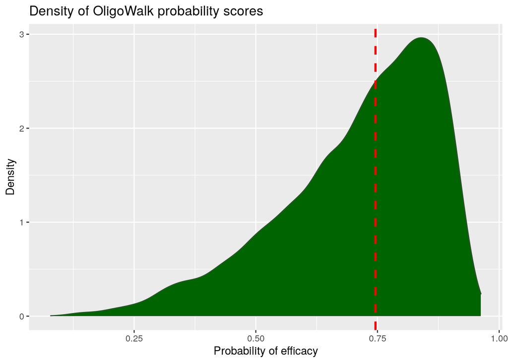

```r
# Kernel Density Plot

p <- ggplot(SARS2.OW, aes(x=OW.prob)) +
  geom_density(color="#2F4F2F", fill="#006400") +
  geom_vline(aes(xintercept=median(OW.prob)), color="red", linetype="dashed", size=1) +
  labs(
    title = "Density of OligoWalk probability scores",
    y = "Density",
    x = "Probability of efficacy")
p
```

### 2.1.3 Summary statistics for OW probabilities

Half of all **8530** identified candidate siRNAs have a probability of efficacy greater than 0.75.

```r
range.summary <- tidy(summary(SARS2.OW$OW.prob, digits = 3))
formattable(range.summary, align = c(rep("c", NCOL(range.summary) - 1)))
```

| minimum | q1 | median | mean | q3 | maximum |
| --- | --- | --- | --- | --- | --- |
| 0.0784 | 0.617 | 0.746 | 0.71 | 0.836 | 0.963 |

### 2.1.4 Genomic overview

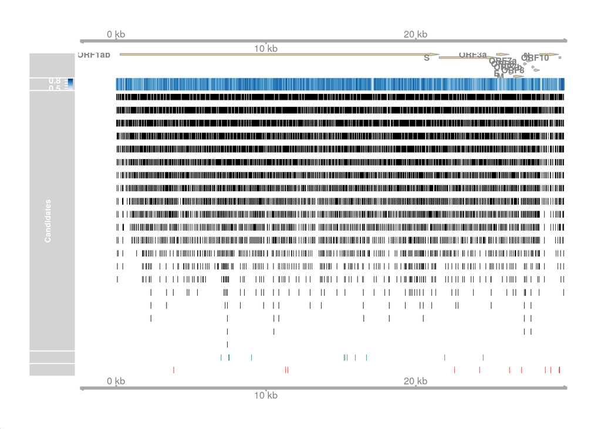

```r
atrack_all <- AnnotationTrack(OW.gr,
                           name = "Candidates",col="transparent",fill="black",size=6,
                           showOverplotting=FALSE)

atrack_top10 <- AnnotationTrack(SARS2.OW.top10.gr,
                           name = "Top",size=4,showTitle=TRUE,
                           fill="seagreen4",col="transparent",
                           showOverplotting=FALSE)
atrack_bottom10 <- AnnotationTrack(SARS2.OW.bottom10.gr,
                           name = "Bottom",size=4,showTitle=TRUE,
                           fill="firebrick2",col="transparent",
                           showOverplotting=FALSE)

dtrack <- DataTrack(OW.gr,
                    name = "P(efficacy)",
                    data = OW.gr$OW.prob,
                    type = "heatmap",size=4,
                    window = "auto")

plotTracks(list(SARS2_gtrack, SARS2_annoTrack, dtrack, atrack_all, atrack_top10, atrack_bottom10, SARS2_gtrack),margin=65)
```

The blue heatmap indicates the distribution of OligoWalk scores along the length of the viral genome, with darker regions bearing more favorable siRNA target sites. All candidates (8530 in total) are shown in the next track, followed by the top 10 candidates in green, the bottom 10 in red.

## 2.2 DSIR Candidates

```r
SARS2.DSIR <- SARS2.data[!is.na(SARS2.data$DSIR.score), grepl("chr|start|end|strand|name|refSeq|DSIR", names(SARS2.data)) ]
```

DSIR implements a simple linear model combining basic sequence features of siRNAs for efficacy prediction. The model enables quantification of the effect of nucleotides at particular positions and of sequence motifs. Analysis of SARS-CoV-2 gRNA resulted in **1646** candidates.

### 2.2.1 Top and bottom 10

Top and bottom 10 candidates, ranked by DSIR’s *score* (`DSIR.score`). The top 10 scores are indicated in green, the bottom 10 in red.

```r
SARS2.DSIR <- SARS2.DSIR[order(SARS2.DSIR$DSIR.score, decreasing = TRUE),]

SARS2.DSIR.top10 <- head(n=10,SARS2.DSIR[ , !grepl("SARS1|prefilter|COH|OW", names(SARS2.DSIR)) ])
SARS2.DSIR.top10$selection <- "TOP_10"
SARS2.DSIR.top10.gr <- makeGRangesFromDataFrame(SARS2.DSIR.top10, keep.extra.columns=TRUE)

SARS2.DSIR.bottom10 <- tail(n=10,SARS2.DSIR[ , !grepl("SARS1|prefilter|COH|OW", names(SARS2.DSIR)) ])
SARS2.DSIR.bottom10$selection <- "BOTTOM_10"
SARS2.DSIR.bottom10.gr <- makeGRangesFromDataFrame(SARS2.DSIR.bottom10, keep.extra.columns=TRUE)

# make a table of both the top 10 and bottom 10
SARS2.DSIR.selection<-rbind(SARS2.DSIR.top10,SARS2.DSIR.bottom10)
rownames(SARS2.DSIR.selection)<-NULL

formattable(SARS2.DSIR.selection,
            align = c(rep("l", 3, ), "c", "l" ,rep("c", NCOL(SARS2.DSIR.selection) - 1)),
            list(name = FALSE,
                 selection = FALSE,
                 DSIR.score = color_tile('firebrick2', 'seagreen4'),
                 refSeq = formatter("span", style=style("font-family" = "courier")),
                 strand = formatter("span", style=style("font-family" = "courier"))))
```

| chr | start | end | strand | refSeq | DSIR.pos | DSIR.AS.Sequence | DSIR.score | DSIR.corr_score |
| --- | --- | --- | --- | --- | --- | --- | --- | --- |
| NC_045512v2 | 13617 | 13637 | + | GGACGAAGATGACAATTTAAT | 13630 | UAAAUUGUCAUCUUCGUCCUU | 111.5 | -24.5 |
| NC_045512v2 | 5921 | 5941 | + | GGTGTTGTTTGTACAGAAATT | 5934 | UUUCUGUACAAACAACACCAU | 107.7 | 48.7 |
| NC_045512v2 | 18117 | 18137 | + | CCTCAGTGTTGACACTAAATT | 18130 | UUUAGUGUCAACACUGAGGUG | 107.2 | -73.8 |
| NC_045512v2 | 7954 | 7974 | + | GCTTATGTGTCAACCTATACT | 7967 | UAUAGGUUGACACAUAAGCUG | 106.6 | 27.6 |
| NC_045512v2 | 18406 | 18426 | + | GGTTATGTTGATACACCTAAT | 18419 | UAGGUGUAUCAACAUAACCUG | 106.0 | -78.0 |
| NC_045512v2 | 23401 | 23421 | + | GGATGTTAACTGCACAGAAGT | 23414 | UUCUGUGCAGUUAACAUCCUG | 105.8 | -128.2 |
| NC_045512v2 | 9248 | 9268 | + | GGTGTTTGTGTATCTACTAGT | 9261 | UAGUAGAUACACAAACACCAG | 105.7 | 13.7 |
| NC_045512v2 | 3319 | 3339 | + | AGTTGTTCAGACTATTGAAGT | 3332 | UUCAAUAGUCUGAACAACUGG | 105.7 | 72.7 |
| NC_045512v2 | 15724 | 15744 | + | GCTGTTGTGTGTTTCAATAGC | 15737 | UAUUGAAACACACAACAGCAU | 105.2 | -51.8 |
| NC_045512v2 | 8571 | 8591 | + | GGTTGAAGCAGTTAATTAAAG | 8584 | UUAAUUAACUGCUUCAACCAA | 105.1 | 20.1 |
| NC_045512v2 | 10156 | 10176 | + | CGTAGTTTACTGTCCAAGACA | 10169 | UCUUGGACAGUAAACUACGUC | 90.0 | -11.0 |
| NC_045512v2 | 3190 | 3210 | + | AGAAGAAGATTGGTTAGATGA | 3203 | AUCUAACCAAUCUUCUUCUUG | 90.0 | 58.0 |
| NC_045512v2 | 6857 | 6877 | + | ATAGCAAAGAATACTGTTAAG | 6870 | UAACAGUAUUCUUUGCUAUAG | 90.0 | 22.0 |
| NC_045512v2 | 5764 | 5784 | + | TGGTCACTATAAACATATAAC | 5777 | UAUAUGUUUAUAGUGACCACA | 90.0 | 33.0 |
| NC_045512v2 | 18901 | 18921 | + | AAGCGTGTTGACTGGACTATT | 18914 | UAGUCCAGUCAACACGCUUAA | 90.0 | -99.0 |
| NC_045512v2 | 17080 | 17100 | + | GGACCACCTGGTACTGGTAAG | 17093 | UACCAGUACCAGGUGGUCCCU | 90.0 | -80.0 |
| NC_045512v2 | 16803 | 16823 | + | AAACAGTAAAGTACAAATAGG | 16816 | UAUUUGUACUUUACUGUUUUU | 90.0 | -78.0 |
| NC_045512v2 | 9856 | 9876 | + | GCTATTACCTCTTACGCAATA | 9869 | UUGCGUAAGAGGUAAUAGCAC | 90.0 | -8.0 |
| NC_045512v2 | 28531 | 28551 | + | CTACCGAAGAGCTACCAGACG | 28544 | UCUGGUAGCUCUUCGGUAGUA | 90.0 | -195.0 |
| NC_045512v2 | 20804 | 20824 | + | AACTGTGTCAATATTTAAACA | 20817 | UUUAAAUAUUGACACAGUUGA | 90.0 | -118.0 |

```r
# save as an excel sheet
write.xlsx(SARS2.DSIR.selection, "../results/SARS2-candidate-siRNA.xlsx", sheetName = "DSIR candidates", col.names = TRUE, row.names = FALSE, append = TRUE)
```

None of the top 10 DSIR candidates were shared with the top 10 OligoWalk candidates.  
DSIR provides an antisense siRNA which includes an overhang.  
DSIR position information doesn’t match with the location of the reported sequence.

### 2.2.2 Distribution of DSIR scores

DSIR filters all candidates with a score cutoff of **90**, so those below are not reported.

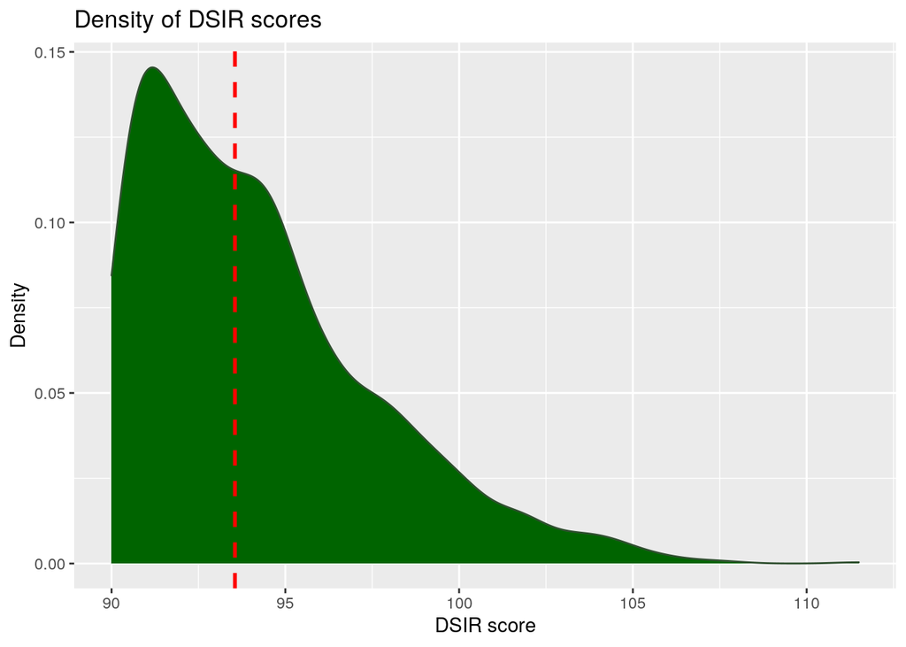

```r
# Kernel Density Plot

p <- ggplot(SARS2.DSIR, aes(x=DSIR.score)) +
  geom_density(color="#2F4F2F", fill="#006400") +
  geom_vline(aes(xintercept=median(DSIR.score)), color="red", linetype="dashed", size=1) +
  labs(
    title = "Density of DSIR scores",
    y = "Density",
    x = "DSIR score")
p
```

### 2.2.3 Summary statistics for DSIR scores

Half of all **1646** identified candidate siRNAs have a DSIR score greater than 93.55.

```r
range.summary <- tidy(summary(SARS2.DSIR$DSIR.score, digits = 4))
formattable(range.summary, align = c(rep("c", NCOL(range.summary) - 1)))
```

| minimum | q1 | median | mean | q3 | maximum |
| --- | --- | --- | --- | --- | --- |
| 90 | 91.5 | 93.55 | 94.24 | 96.1 | 111.5 |

### 2.2.4 Genomic overview

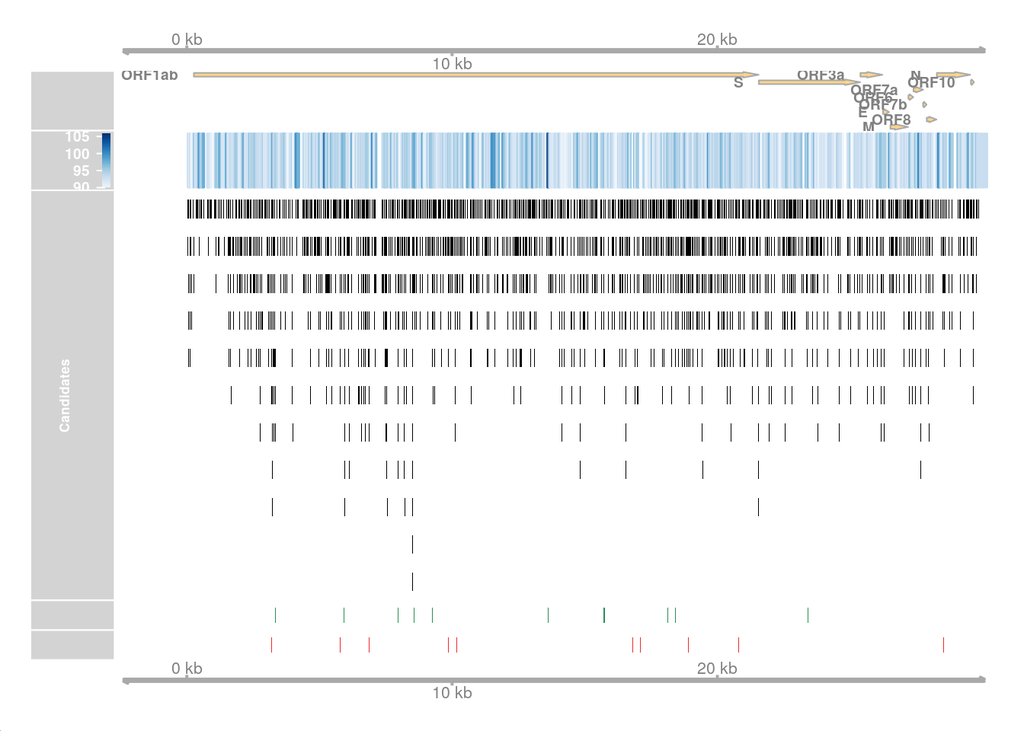

```r
dtrack <- DataTrack(DSIR.gr,
                    name = "DSIR score",
                    data = DSIR.gr$DSIR.score,
                    type = "heatmap",
                    window = "auto" ,
                    size = 8)

atrack_all <- AnnotationTrack(DSIR.gr,
                           name = "Candidates",col="transparent",size=5,fill="black",
                           showOverplotting=FALSE)

atrack_top10 <- AnnotationTrack(SARS2.DSIR.top10.gr,
                           name = "Top",
                           fill="seagreen4",size=4,col="transparent",
                           showOverplotting=FALSE)

atrack_bottom10 <- AnnotationTrack(SARS2.DSIR.bottom10.gr,
                           name = "Bottom",
                           fill="firebrick2",size=4,col="transparent",
                           showOverplotting=FALSE)


plotTracks(list(SARS2_gtrack, SARS2_annoTrack,  dtrack, atrack_all, atrack_top10, atrack_bottom10 , SARS2_gtrack),margin=40)
```

## 2.3 COH (Tristan’s) Candidates

### 2.3.1 Top and bottom 10

Top and bottom 10 candidates, ranked by OligoWalk’s *probability of efficacy score* (`OW.prob`). The top 10 scores are indicated in green, the bottom 10 in red.

```r
SARS2.COH <- SARS2.data[!is.na(SARS2.data$COH.name), grepl("chr|start|end|strand|COH.name|refSeq|OW.prob", names(SARS2.data)) ]

SARS2.COH <- SARS2.COH[order(SARS2.COH$OW.prob, decreasing = TRUE),]

SARS2.COH.top10 <- head(n=10,SARS2.COH[ , !grepl("SARS1|OW.end_diff", names(SARS2.COH)) ])
SARS2.COH.top10$selection <- "TOP_10"
SARS2.COH.top10.gr <- makeGRangesFromDataFrame(SARS2.COH.top10, keep.extra.columns=TRUE)


SARS2.COH.bottom10 <- tail(n=10,SARS2.COH[ , !grepl("SARS1|OW.end_diff", names(SARS2.COH)) ])
SARS2.COH.bottom10$selection <- "BOTTOM_10"
SARS2.COH.bottom10.gr <- makeGRangesFromDataFrame(SARS2.COH.bottom10, keep.extra.columns=TRUE)

# make a table of both the top 10 abd bottom 10
SARS2.COH.selection<-rbind(SARS2.COH.top10,SARS2.COH.bottom10)
rownames(SARS2.COH.selection)<-NULL

formattable(SARS2.COH.selection,
            align = c(rep("l", 3, ), "c", "l" ,rep("c", NCOL(SARS2.COH.selection) - 1)),
            list(name = FALSE,
                 selection = FALSE,
                 OW.prob = color_tile('firebrick2', 'seagreen4'),
                 refSeq = formatter("span", style=style("font-family" = "courier")),
                 strand = formatter("span", style=style("font-family" = "courier"))))
```

| chr | start | end | strand | refSeq | OW.prob | COH.name |
| --- | --- | --- | --- | --- | --- | --- |
| NC_045512v2 | 418 | 438 | + | TGGCTTAGTAGAAGTTGAAAA | 0.933432 | Si-UTR-2 |
| NC_045512v2 | 48 | 68 | + | CTCTTGTAGATCTGTTCTCTA | 0.916314 | Si-L1 |
| NC_045512v2 | 23955 | 23975 | + | GTGGTTTTAATTTTTCACAAA | 0.871186 | Si-S-2 |
| NC_045512v2 | 17773 | 17793 | + | TCACCTTATAATTCACAGAAT | 0.861427 | Si-UC-RdRp-6 |
| NC_045512v2 | 29001 | 29021 | + | GCCAAACTGTCACTAAGAAAT | 0.834591 | Si-N-2 |
| NC_045512v2 | 26728 | 26748 | + | CTGTTTACAGAATAAATTGGA | 0.806957 | Si_M-1 |
| NC_045512v2 | 27119 | 27139 | + | CAGGATTGGCAACTATAAATT | 0.783510 | Si_M-5 |
| NC_045512v2 | 23956 | 23976 | + | TGGTTTTAATTTTTCACAAAT | 0.747434 | Si-S-1 |
| NC_045512v2 | 47 | 67 | + | TCTCTTGTAGATCTGTTCTCT | 0.675145 | SiL-2 |
| NC_045512v2 | 26589 | 26609 | + | GTAATAGGTTTCCTATTCCTT | 0.506914 | Si-M-9 |
| NC_045512v2 | 27387 | 27407 | + | AACGAACATGAAAATTATTCT | NA | Si-7a-1 |
| NC_045512v2 | 28998 | 29018 | + | AAGGCCAAACTGTCACTAAGA | NA | Si-N-1 |
| NC_045512v2 | 15087 | 15107 | + | TGCAAAGAATAGAGCTCGCAC | NA | Si-UC-RdRp-4 |
| NC_045512v2 | 17830 | 17850 | + | ACTGTTGATTCATCACAGGGC | NA | Si-UC-RdRp-5 |
| NC_045512v2 | 10 | 30 | + | TTATACCTTCCCAGGTAACAA | NA | Si-UTR-3 |
| NC_045512v2 | 276 | 296 | + | TTGTCCCTGGTTTCAACGAGA | NA | Si-UTR-1 |
| NC_045512v2 | 403 | 423 | + | TAAAGATGGCACTTGTGGCTT | NA | Si-UTR-4 |
| NC_045512v2 | 278 | 298 | + | GTCCCTGGTTTCAACGAGAAA | NA | Si-UTR-5 |
| NC_045512v2 | 26726 | 26746 | + | TGCTGTTTACAGAATAAATTG | NA | Si_M-2 |
| NC_045512v2 | 26540 | 26560 | + | TACTATTACCGTTGAAGAGCT | NA | Si_M-3 |

```r
# save as an excel sheet
write.xlsx(SARS2.COH.selection, "../results/SARS2-candidate-siRNA.xlsx", sheetName = "COH candidates", col.names = TRUE, row.names = FALSE, append = TRUE)
```

Note that not all COH candidates have an OligoWalk probability assigned, suggesting these fall below OligoWalk’s efficacy threshold.

### 2.3.2 Genomic overview

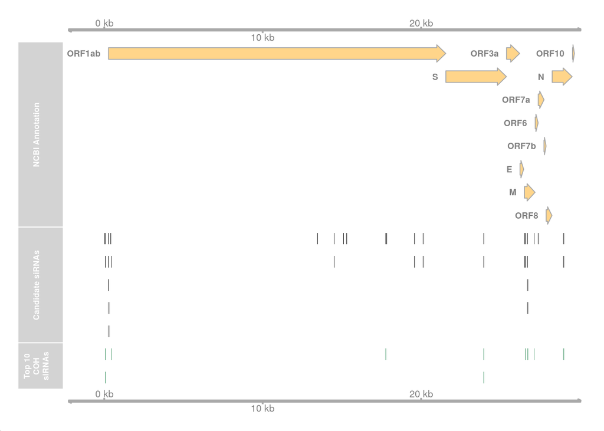

```r
atrack_all <- AnnotationTrack(COH.gr,
                           name = "Candidate siRNAs",col="transparent",fill="black",
                           showOverplotting=FALSE)

atrack_top10 <- AnnotationTrack(SARS2.COH.top10.gr,
                           name = "Top 10 COH siRNAs",
                           fill="seagreen4",col="transparent",
                           showOverplotting=FALSE)



plotTracks(list(SARS2_gtrack, SARS2_annoTrack, atrack_all, atrack_top10, SARS2_gtrack),margin=40)
```

Top 10 candidates are shown in green. The bottom 10 candidates as ranked by OligoWalk are arbitrary (see above) so are omitted from this plot.

## 2.4 VIRsiRNAdb candidates shared with SARS1

[VIRsiRNAdb](http://crdd.osdd.net/servers/virsirnadb/) is a curated database of experimentally validated viral siRNA/shRNA targeting diverse genes of 42 important human viruses including influenza, SARS and Hepatitis viruses.

In total, VIRsiRNAdb reports 163 published and validated siRNAs from SARS-CoV-1, and 61 have a ‘hit’ in SARS-CoV-2 with no more than 2 mismatches.

### 2.4.1 Top and bottom 10

Top and bottom 10 candidates, ranked by experimental efficacy (`Efficacy`). The top 10 scores are indicated in green, the bottom 10 in red.

```r
SARS2.VIRsiDB <- SARS2.data[!is.na(SARS2.data$VIRsiRNAid), grepl("chr|start|end|strand|refSeq|VIRsiRNAid|Target_Region|Cell_Line|Test_Object|Efficacy|PMID|OW.prob|DSIR.score|COH.name", names(SARS2.data)) ]

SARS2.VIRsiDB$Efficacy <- gsub("Low",33,SARS2.VIRsiDB$Efficacy)
SARS2.VIRsiDB$Efficacy <- gsub("Medium",55,SARS2.VIRsiDB$Efficacy)
SARS2.VIRsiDB$Efficacy <- gsub("High",99,SARS2.VIRsiDB$Efficacy)
SARS2.VIRsiDB$Efficacy <- as.numeric(SARS2.VIRsiDB$Efficacy)

SARS2.VIRsiDB <- SARS2.VIRsiDB[order(SARS2.VIRsiDB$Efficacy, decreasing = TRUE),]

SARS2.VIRsiDB.top10 <- head(n=10,SARS2.VIRsiDB[ , !grepl("SARS1|OW.end_diff|COH.name", names(SARS2.VIRsiDB)) ])
SARS2.VIRsiDB.top10$selection <- "TOP_10"
SARS2.VIRsiDB.top10.gr <- makeGRangesFromDataFrame(SARS2.VIRsiDB.top10, keep.extra.columns=TRUE)

SARS2.VIRsiDB.bottom10 <- tail(n=10,SARS2.VIRsiDB[ , !grepl("SARS1|OW.end_diff|COH.name", names(SARS2.VIRsiDB)) ])
SARS2.VIRsiDB.bottom10$selection <- "BOTTOM_10"
SARS2.VIRsiDB.bottom10.gr <- makeGRangesFromDataFrame(SARS2.VIRsiDB.bottom10, keep.extra.columns=TRUE)

# make a table of both the top 10 and bottom 10
SARS2.VIRsiDB.selection<-rbind(SARS2.VIRsiDB.top10,SARS2.VIRsiDB.bottom10)
rownames(SARS2.VIRsiDB.selection)<-NULL

formattable(SARS2.VIRsiDB.selection,
            align = c(rep("l", 3, ), "c", "l" ,rep("c", NCOL(SARS2.VIRsiDB.selection) - 1)),
            list(name = FALSE,
                 selection = FALSE,
                 Efficacy = color_tile('firebrick2', 'seagreen4'),
                 refSeq = formatter("span", style=style("font-family" = "courier")),
                 strand = formatter("span", style=style("font-family" = "courier")),
                 PMID   = formatter("a", href = x ~ sprintf("https://pubmed.ncbi.nlm.nih.gov/%s/", x))))
```

| chr | start | end | strand | refSeq | OW.prob | DSIR.score | VIRsiRNAid | Target_Region | Cell_Line | Test_Object | Efficacy | PMID |
| --- | --- | --- | --- | --- | --- | --- | --- | --- | --- | --- | --- | --- |
| NC_045512v2 | 24697 | 24715 | + | GGGCTATCATCTTATGTCC | NA | NA | virsi1289 | Spike | Vero E6 | mRNA | 100 | [14988013](https://pubmed.ncbi.nlm.nih.gov/14988013/) |
| NC_045512v2 | 26362 | 26382 | + | TGTGCGTACTGCTGCAATATT | 0.616669 | NA | virsi2254 | ORF4, E-Protein | FRhK-4 | Viral Titer | 99 | [15259899](https://pubmed.ncbi.nlm.nih.gov/15259899/) |
| NC_045512v2 | 14843 | 14863 | + | AACTACTATTTGTAGTTGAAG | NA | NA | virsi2232 | ORF1b, NSP-13 | FRhK-4 | Viral Titer | 99 | [15259899](https://pubmed.ncbi.nlm.nih.gov/15259899/) |
| NC_045512v2 | 16841 | 16861 | + | AAGGTGACTATGGTGATGCTG | NA | NA | virsi2233 | ORF1b, NSP-13 | FRhK-4 | Viral Titer | 99 | [15259899](https://pubmed.ncbi.nlm.nih.gov/15259899/) |
| NC_045512v2 | 23079 | 23099 | + | AACCATACAGAGTAGTAGTAC | NA | NA | virsi2241 | ORF2, Spike | FRhK-4 | Viral Titer | 99 | [15259899](https://pubmed.ncbi.nlm.nih.gov/15259899/) |
| NC_045512v2 | 26127 | 26147 | + | AATTCACACAATCGACGGTTC | NA | NA | virsi2250 | ORF3a | FRhK-4 | Viral Titer | 99 | [15259899](https://pubmed.ncbi.nlm.nih.gov/15259899/) |
| NC_045512v2 | 26264 | 26284 | + | AAGAGACAGGTACGTTAATAG | NA | NA | virsi2251 | ORF4, E-Protein | FRhK-4 | Viral Titer | 99 | [15259899](https://pubmed.ncbi.nlm.nih.gov/15259899/) |
| NC_045512v2 | 26280 | 26300 | + | AATAGTTAATAGCGTACTTCT | NA | NA | virsi2252 | ORF4, E-Protein | FRhK-4 | Viral Titer | 99 | [15259899](https://pubmed.ncbi.nlm.nih.gov/15259899/) |
| NC_045512v2 | 29336 | 29356 | + | AAGCATATTGACGCATACAAA | NA | NA | virsi2253 | ORF4, E-Protein | FRhK-4 | Viral Titer | 99 | [15259899](https://pubmed.ncbi.nlm.nih.gov/15259899/) |
| NC_045512v2 | 26583 | 26603 | + | AACCTAGTAATAGGTTTCCTA | NA | NA | virsi2257 | ORF5, M-Protein | FRhK-4 | Viral Titer | 99 | [15259899](https://pubmed.ncbi.nlm.nih.gov/15259899/) |
| NC_045512v2 | 28649 | 28669 | + | AACAAAGACGGCATCATATGG | NA | NA | virsi1378 | N | Vero E6 | mRNA | 26 | [15780182](https://pubmed.ncbi.nlm.nih.gov/15780182/) |
| NC_045512v2 | 26310 | 26330 | + | TTTCGTGGTATTCTTGCTAGT | NA | NA | virsi1447 | Env | Vero E6 | mRNA | 26 | [15780182](https://pubmed.ncbi.nlm.nih.gov/15780182/) |
| NC_045512v2 | 26278 | 26298 | + | TTAATAGTTAATAGCGTACTT | NA | NA | virsi1997 | Env | Vero E6 | mRNA | 26 | [15780182](https://pubmed.ncbi.nlm.nih.gov/15780182/) |
| NC_045512v2 | 27128 | 27148 | + | CAACTATAAATTAAACACAGA | NA | NA | virsi1383 | M | Vero E6 | mRNA | 23 | [15780182](https://pubmed.ncbi.nlm.nih.gov/15780182/) |
| NC_045512v2 | 57 | 75 | + | ATCTGTTCTCTAAACGAAC | NA | NA | virsi1351 | TRS | Vero E6 | RNA | 20 | [15652970](https://pubmed.ncbi.nlm.nih.gov/15652970/) |
| NC_045512v2 | 26424 | 26442 | + | TCGTGTTAAAAATCTGAAT | NA | NA | virsi1320 | Env | 293T | Protein | 15 | [17139181](https://pubmed.ncbi.nlm.nih.gov/17139181/) |
| NC_045512v2 | 28646 | 28664 | + | GCTAACAAAGACGGCATCA | NA | NA | virsi1316 | N | COS-7 | Protein | 14 | [17139181](https://pubmed.ncbi.nlm.nih.gov/17139181/) |
| NC_045512v2 | 29575 | 29593 | + | TTTCGCTTTTCCGTTTACG | NA | NA | virsi1348 | 3’UTR | Vero E6 | RNA | 10 | [15652970](https://pubmed.ncbi.nlm.nih.gov/15652970/) |
| NC_045512v2 | 28537 | 28557 | + | AAGAGCTACCAGACGAATTCG | NA | NA | virsi1380 | N | Vero E6 | mRNA | 8 | [15780182](https://pubmed.ncbi.nlm.nih.gov/15780182/) |
| NC_045512v2 | 28646 | 28664 | + | GCTAACAAAGACGGCATCA | NA | NA | virsi1325 | N | 293T | Protein | 6 | [17139181](https://pubmed.ncbi.nlm.nih.gov/17139181/) |

```r
# save as an excel sheet
write.xlsx(SARS2.VIRsiDB.selection, "../results/SARS2-candidate-siRNA.xlsx", sheetName = "VIRsiRNADB candidates", col.names = TRUE, row.names = FALSE, append = TRUE)
```

Efficacy of 99 indicates VIRsiDB ranked the Efficacy as “High”: see the explanation below. As for the COH set, the top 10 and bottom 10 are somewhat arbitrary.  
Only one experimentally validated siRNA (*virsi2254*) was shared with the candidates suggested by OligoWalk; none was common to the DSIR or the COH set.

### 2.4.2 Distribution of VIRsiDB efficacy scores

VIRsiDB reports *Efficacy* for some siRNAs as `low`, `medium` or `high`, and gives a numeric value between 1 and 100 for others. To combine these for ranking, as no siRNA had an *Efficacy* of 33, 55 or 99, such values were substituted with `low`, `medium` and `high` *Efficacy*, respectively.

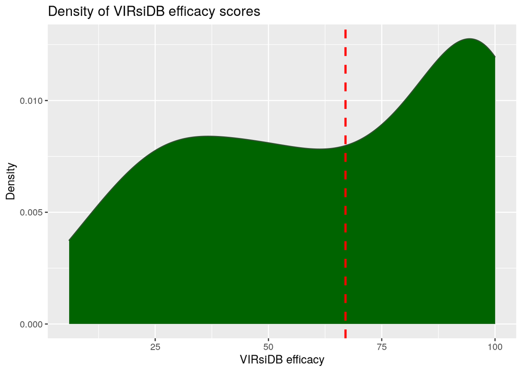

```r
# Kernel Density Plot

p <- ggplot(SARS2.VIRsiDB, aes(x=Efficacy)) +
  geom_density(color="#2F4F2F", fill="#006400") +
  geom_vline(aes(xintercept=median(Efficacy)), color="red", linetype="dashed", size=1) +
  labs(
    title = "Density of VIRsiDB efficacy scores",
    y = "Density",
    x = "VIRsiDB efficacy")
p
```

### 2.4.3 Summary statistics for VIRsiDB Efficacy scores

```r
range.summary <- tidy(summary(SARS2.VIRsiDB$Efficacy, digits = 4))

formattable(range.summary,
            align = c(rep("c", NCOL(range.summary) - 1)))
```

| minimum | q1 | median | mean | q3 | maximum |
| --- | --- | --- | --- | --- | --- |
| 6 | 35 | 67 | 64.43 | 99 | 100 |

### 2.4.4 Genomic overview

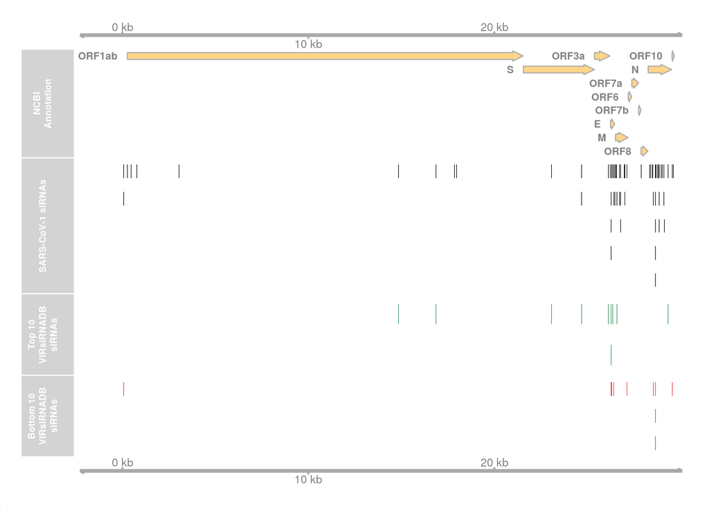

```r
atrack_all <- AnnotationTrack(VIRsiDB.gr,
                           name = "SARS-CoV-1 siRNAs",size = 2,fill="black",col="transparent",
                           showOverplotting=FALSE)

atrack_top10 <- AnnotationTrack(SARS2.VIRsiDB.top10.gr,
                           name = "Top 10 VIRsiRNADB siRNAs",
                           fill="seagreen4",size = 3,col="transparent",
                           showOverplotting=FALSE)
atrack_bottom10 <- AnnotationTrack(SARS2.VIRsiDB.bottom10.gr,
                           name = "Bottom 10 VIRsiRNADB siRNAs",
                           fill="firebrick2",size = 2,col="transparent",
                           showOverplotting=FALSE)

plotTracks(list(SARS2_gtrack, SARS2_annoTrack, atrack_all, atrack_top10, atrack_bottom10, SARS2_gtrack),margin=40)
```

# 3 Filters

To narrow the list of 9442 candidates, we filter based on various criteria including sequence conservation, secondary structure, putative off-target effects and viral RNA modifications.

## 3.1 Conservation

### 3.1.1 Conserved 21bp windows in GISAID SARS-Cov-2 full length genomes

[figure not shown]

```r
dtrack_all <- DataTrack(SARS2.gr,
                           data = SARS2.gr$gisaid.freq,
                           type = "histogram", size=12,
                           window = "auto",
                           name = "GISAID")

gisaid_SARS2.gr <- SARS2.gr[values(SARS2.gr)[ ,"gisaid.freq"] >= quantile(SARS2.gr$gisaid.freq, probs = 0.9) ]
gisaid_filtered    <- nrow(values(gisaid_SARS2.gr))

atrack_all  <- AnnotationTrack(gisaid_SARS2.gr, strand = "*", col="transparent",fill="black",
                           name = "Candidates in 90th percentile windows",
                           showOverplotting=FALSE)


plotTracks(list(SARS2_gtrack, SARS2_annoTrack,  dtrack_all, atrack_all, SARS2_gtrack),margin=60)
```

The GISAID Initiative makes available SARS-CoV-2 viral genomic sequences collected from infected patients globally. We counted the frequency of 21 bp windows from the reference sequence in 64361 SARS-CoV-2 genomes. The highest scoring siRNAs are common to 64275 genomes; the lowest occur in just 5379. Candidates in the 90th percentile number 949, or 10.05% of all candidates.

### 3.1.2 Conserved 21bp windows between SARS-Cov-2 and SARS-Cov-1

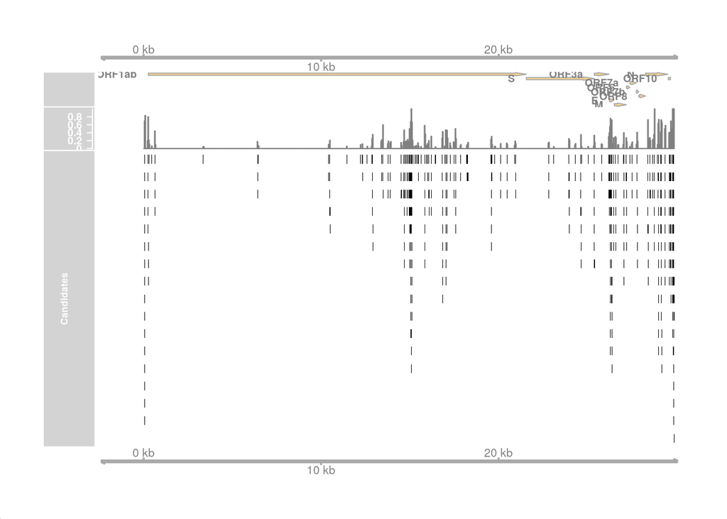

```r
dtrack_all <- DataTrack(SARS2.gr,
                           data = SARS2.gr$SARS1.freq,
                           type = "histogram",
                           window = "auto",size=10,
                           name = "Frequency of colinear windows")

SARS1_SARS2.gr     <- SARS2.gr[values(SARS2.gr)[ ,"SARS1.freq"] >= 1 ]
SARS1_filtered     <- nrow(values(SARS1_SARS2.gr))
SARS1_numIntervals <- length(subsetByOverlaps(SARS2.gr,SARS1_SARS2.gr))
#SARS1_SARS2.gr     <- GenomicRanges::reduce(SARS1_SARS2.gr)
SARS1_length       <- sum(width(SARS1_SARS2.gr))

atrack_all         <- AnnotationTrack(SARS1_SARS2.gr, strand = "*",
                           name = "Candidates",size=4,fill="black",col="transparent",
                           showOverplotting=FALSE)


plotTracks(list(SARS2_gtrack, SARS2_annoTrack,  dtrack_all, atrack_all, SARS2_gtrack),margin=80)
```

To find siRNAs that might be effective against both SARS-CoV-2 and SARS-CoV-1, we identified 1411 colinear stretches of 21 bp with ≤ 2 mismatches in both reference genomes, totaling 9163bp. Candidates that fall in these windows number 437, or 4.63% of all candidates.

### 3.1.3 Multiz 44 way conservation (SARS-Cov-2, SARS-Cov-1, other bat corona viruses)

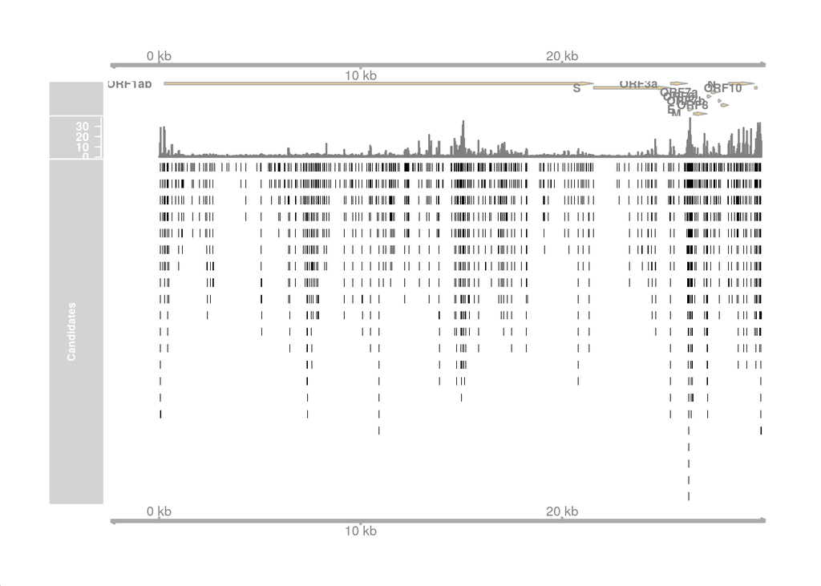

```r
dtrack_all <- DataTrack(SARS2.gr,
                           data = SARS2.gr$MULTIZ44.freq,
                           type = "histogram", size=10,
                           window = "auto",
                           name = "MULTIZ44")

MULTIZ44_SARS2.gr <- SARS2.gr[values(SARS2.gr)[ ,"MULTIZ44.freq"] >= quantile(SARS2.gr$MULTIZ44.freq, probs = 0.9) ]
MULTIZ44_filtered    <- nrow(values(MULTIZ44_SARS2.gr))

#MULTIZ44_SARS2.gr <-GenomicRanges::reduce(MULTIZ44_SARS2.gr)
atrack_all  <- AnnotationTrack(MULTIZ44_SARS2.gr, strand = "*",
                           name = "Candidates", size=4,fill="black",col="transparent",
                           showOverplotting=FALSE)


plotTracks(list(SARS2_gtrack, SARS2_annoTrack, dtrack_all, atrack_all,  SARS2_gtrack),margin=80)
```

To assess conservation of 21bp windows in bat coronaviruses, we made use of the [UCSC MULTIZ 44-way](https://genome.ucsc.edu/cgi-bin/hgTrackUi?hgsid=860479219_eVciNP0iuq77VaGAJcexqe7UCzDo&c=NC_045512v2&g=strainCons44way) multiple species fasta, which includes 44 strains with bats as hosts. The higest scoring siRNAs are common to 44 genomes; the lowest occur in just 1. Candidates in the 90th percentile number 1606, or 17.01% of all candidates.

### 3.1.4 Multiz 119 way conservation (Coronavirus strains with vertebrate hosts and human SARS-CoV-2)

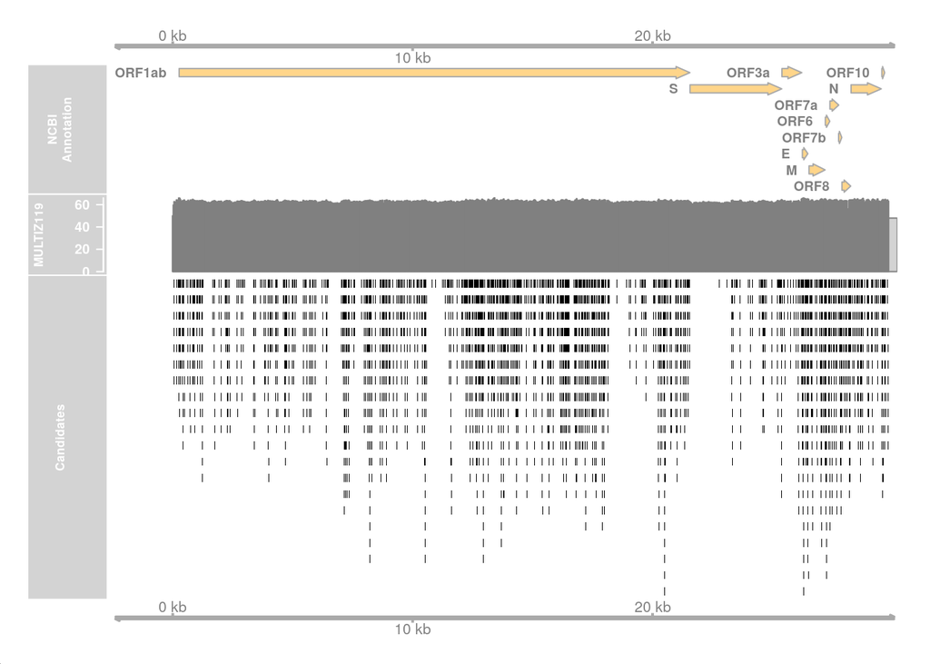

```r
dtrack_all <- DataTrack(SARS2.gr,
                           data = SARS2.gr$MULTIZ119.freq,
                           type = "histogram",
                           window = "auto",
                           name = "MULTIZ119")

MULTIZ119_SARS2.gr <- SARS2.gr[values(SARS2.gr)[ ,"MULTIZ119.freq"] >= quantile(SARS2.gr$MULTIZ119.freq, probs = 0.9) ]
MULTIZ119_filtered <- nrow(values(MULTIZ119_SARS2.gr))

#MULTIZ119_SARS2.gr <-GenomicRanges::reduce(MULTIZ119_SARS2.gr)
atrack_all  <- AnnotationTrack(MULTIZ119_SARS2.gr, strand = "*",
                           name = "Candidates", fill="black",col="transparent",
                           showOverplotting=FALSE)


plotTracks(list(SARS2_gtrack, SARS2_annoTrack, dtrack_all, atrack_all,  SARS2_gtrack), margin = 40)
```

To assess conservation of 21bp windows at a greater phylogenetic depth, we made use of the [UCSC MULTIZ 119-way](https://genome.ucsc.edu/cgi-bin/hgTrackUi?hgsid=860479219_eVciNP0iuq77VaGAJcexqe7UCzDo&c=NC_045512v2&g=strainCons119way) multiple species fasta, which includes 119 strains with vertebrate hosts (55 strains) and human SARS-Cov2 (62 isolates). The highest scoring siRNAs are common to 67 genomes; the lowest occur in just 20. Candidates in the 90th percentile number 3127, or 33.12% of all candidates.

## 3.2 Structure

RNA secondary structure is thought to play an important role in siRNA efficacy. Several methods exist to assess the stability of mRNA secondary structures and the duplexes they form with cognate siRNAs. Thermodynamically unstable regions are consistent with the absence of defined structures that might preclude siRNA access, and so are preferred target sites.

### 3.2.1 Rangan et al 2020

> Rangan R, Zheludev IN, Hagey RJ, et al. RNA genome conservation and secondary structure in SARS-CoV-2 and SARS-related viruses: a first look. RNA. 2020;26(8):937-959. doi:10.1261/rna.076141.120

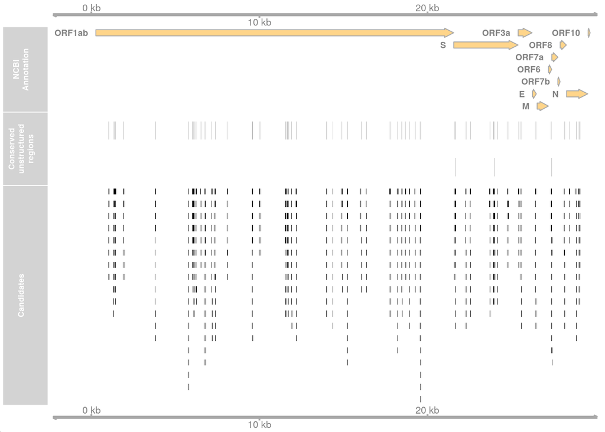

```r
# number and length of intervals
rangan_length       <- sum(width(rangan.Table3.cons_unstr.gr))
rangan_numIntervals <- length(rangan.Table3.cons_unstr.gr)
# number of siRNAs within intervals
rangan_SARS2.gr     <- subsetByOverlaps(SARS2.gr,rangan.Table3.cons_unstr.gr)
rangan_filtered     <- nrow(values(rangan_SARS2.gr))

dtrack_all <- AnnotationTrack(rangan.Table3.cons_unstr.gr,
                           name = "Conserved unstructured regions",
                           showTitle=TRUE, size=3,col="transparent",fill="gray")

atrack_all  <- AnnotationTrack(rangan_SARS2.gr, strand = "*",
                          name = "Candidates",fill="black",col="transparent",
                         collapse=TRUE)

plotTracks(list(SARS2_gtrack, SARS2_annoTrack, dtrack_all,atrack_all, SARS2_gtrack))
```

In **Table 3**, Rangan *et al* present 58 conserved, unstructured regions of the SARS-CoV-2 genome (A), totaling 997 base pairs. The conserved, unstructured regions include 688 siRNAs, or 7.29% of all candidates (bottom track).

### 3.2.2 Andrews et al 2020

> Andrews RJ, Peterson JM, Haniff HS, et al. An in silico map of the SARS-CoV-2 RNA Structurome. Preprint. bioRxiv. 2020;2020.04.17.045161. Published 2020 Apr 18. doi:10.1101/2020.04.17.045161

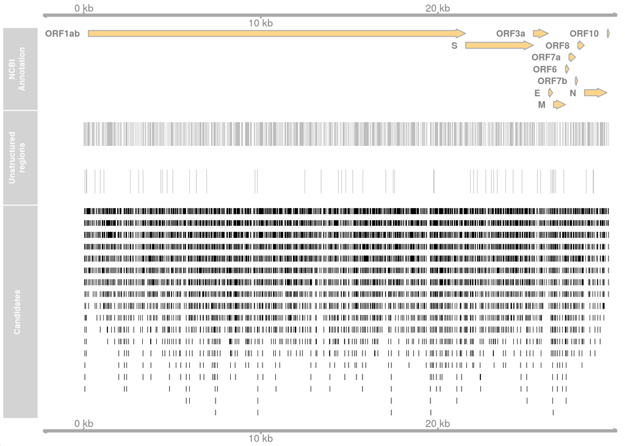

```r
andrews_unstructured.gr<- gaps(andrews.scanfold.gr)

# number and length of intervals
andrews_length       <- sum(width(andrews_unstructured.gr))
andrews_numIntervals <- length(andrews_unstructured.gr)
# number of siRNAs within intervals
andrews_SARS2.gr <- subsetByOverlaps(SARS2.gr,andrews_unstructured.gr)
andrews_filtered    <- nrow(values(andrews_SARS2.gr))

dtrack_all <- AnnotationTrack(andrews_unstructured.gr,
                           name = "Unstructured regions",fill="gray",col="transparent",size=4,
                           showTitle=TRUE,  strand="*")

atrack_all  <- AnnotationTrack(andrews_SARS2.gr, strand = "*",
                          name = "Candidates",fill="black",col="transparent",
                         collapse=TRUE)

plotTracks(list(SARS2_gtrack, SARS2_annoTrack, dtrack_all,atrack_all, SARS2_gtrack))
```

In [**Supplementary Dataset 1**](https://structurome.bb.iastate.edu/sars-cov-2), Andrews *et al* present ScanFold results for 524 regions that are likely highly-structured, where stretches of at least one base pair with an average Z-score < -1 were extracted and refolded. To infer unstructured regions, we take the inverse (A) of the structured intervals, totalling 478 ranges covering 10649 base pairs. The unstructured regions include 6226 siRNAs, or 65.94% of all candidates (bottom track).

## 3.3 Off-targets

Unintended off-target silencing is common in siRNA experiments, particularly via “microRNA-like” effects where siRNA-induced sequence-dependent regulation of transcripts occurs through partial sequence complementarity to 3′ UTRs of off-target transcripts, producing false-positives (Jackson et al. 2006; Jackson and Linsley 2010). To avoid such effects, we counted the frequency of “seed sequences” (base pairs 2-8 at the 5′ end of candidate siRNAs) in the human transcriptome ([Gencode v34](https://www.gencodegenes.org/human/release_34.html), released 11.2019 Transcript sequences), and ranked candidate siRNAs accordingly.

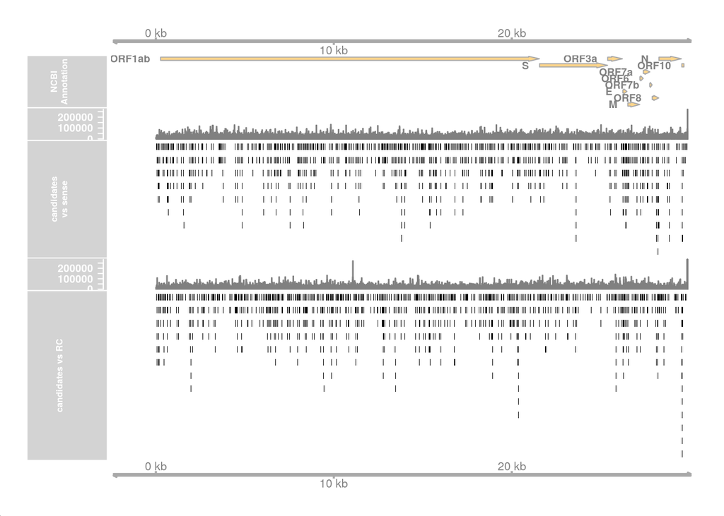

```r
dtrack_all <- DataTrack(SARS2.gr,
                           data = SARS2.gr$gencode.freq,
                           type = "histogram",
                           collapse = FALSE,
                           name = "Gencode")

gencode_SARS2.gr <- SARS2.gr[values(SARS2.gr)[ ,"gencode.freq"] <= quantile(SARS2.gr$gencode.freq, probs = 0.1) ]
gencode_filtered    <- nrow(values(gencode_SARS2.gr))

#gencode_SARS2.gr <-GenomicRanges::reduce(gencode_SARS2.gr)
atrack_all  <- AnnotationTrack(gencode_SARS2.gr, strand = "*",
                           name = "candidates vs sense", fill="black",col="transparent",size=2,
                           showOverplotting=FALSE)
####
dtrack_RC <- DataTrack(SARS2.gr,
                           data = SARS2.gr$gencodeRC.freq,
                           type = "histogram",
                           collapse = FALSE,
                           name = "GencodeRC")

gencodeRC_SARS2.gr <- SARS2.gr[values(SARS2.gr)[ ,"gencodeRC.freq"] <= quantile(SARS2.gr$gencodeRC.freq, probs = 0.1) ]
gencodeRC_filtered    <- nrow(values(gencodeRC_SARS2.gr))

#gencodeRC_SARS2.gr <-GenomicRanges::reduce(gencodeRC_SARS2.gr)
atrack_RC  <- AnnotationTrack(gencodeRC_SARS2.gr, strand = "*",
                           name = "candidates vs RC",fill="black",col="transparent",size=2,
                           showOverplotting=FALSE)
###

plotTracks(list(SARS2_gtrack, SARS2_annoTrack, dtrack_all,atrack_all, dtrack_RC, atrack_RC,SARS2_gtrack),margin=50 )
```

It’s not clear to me if we should consider the viral sense strand (refSeq) or antisense (RC, reverse compliment) - as such I’ve presented counts of seeds in both the transcriptome and the RC transcriptome. For filters, I’ve used gencodeRC counts.

Candidates below the 10th percentile number 945 siRNAs, or 10.01% of all candidates. When the potential targets are considered in sense, coincidentally 945 siRNAs, or 10.01% of all candidates also fall in the bottom 10th percentile with respect to seed frequency in the transcriptome. Even though the number of candidates is identical for the two filters, the composition of candidates differs.

## 3.4 Modified sites

> Kim D, Lee JY, Yang JS, Kim JW, Kim VN, Chang H. The Architecture of SARS-CoV-2 Transcriptome. Cell. 2020;181(4):914-921.e10. doi:10.1016/j.cell.2020.04.011

[figure not shown]

```r
#- join the two Kim granges
kim.mod_motif.gr<- GenomicRanges::reduce(import.bed("beds/kim.mod_motif.bed", genome = "wuhCor1"))
kim.mod_sites.gr<- GenomicRanges::reduce(import.bed("beds/kim.mod_sites.bed", genome = "wuhCor1"))
#- join into one grange
kim.mod.gr<- c(kim.mod_sites.gr, kim.mod_motif.gr)
#- find overlapping siRNAs
kim.mod.SARS2 <- subsetByOverlaps(SARS2.gr, kim.mod.gr)

kim_filtered    <- nrow(values(kim.mod.SARS2))


motifs_track_all  <- AnnotationTrack(kim.mod_motif.gr, strand = "*",
                           name = "motifs",fill="gray",col="transparent",
                           showOverplotting=FALSE)

sites_track_all  <- AnnotationTrack(kim.mod_sites.gr, strand = "*",
                           name = "sites",fill="blue",col="transparent",
                           showOverplotting=FALSE)
atrack_both <- OverlayTrack(trackList=list(motifs_track_all,sites_track_all))

plotTracks(list(SARS2_gtrack, SARS2_annoTrack, atrack_both, SARS2_gtrack), margin = 20)
```

[Kim et al 2020](https://doi.org/10.1016/j.cell.2020.04.011) produced a high-resolution map of the SARS-CoV-2 transcriptome and epitranscriptome using NanoPore sequencing. They report 41 potential modification sites (shown in blue) and that the most frequently observed motif harbouring madifications is AAGAA (77 sites, shown in grey). Modification of sites at an “AAGAA-like” motif are found throughout the viral genome and enriched in genomic positions 28,500–29,500. Long viral transcripts (gRNA, S, 3a, E, and M) are modified more often than shorter mRNAs (6, 7a, 7b, 8, and N) suggesting a transcript-specific modification mechanism. This observation hints at a functional role for modified sites, and so provides potential siRNA targets - 770 candidates (8.16%) overlap with modified sites or an AAGAA motif.

# 4 Selected siRNAs

To select a final list of candidates, we take the full list of 9442 candidates and keep those that that are, in order:

- In structurally accessable regions of the SARS-CoV-2 genome (*viz.* Rangan et al, 688; Andrews et al , 6226)
- In the 90th percentile with respect to frequency in sequenced (GISAID) SARS-CoV-2 genomes (949)
- Common to both SARS-CoV-1 and SARS-CoV-2 (437)
- In the 90th percentile with respect to sequence conservation in bat betacoronavirusus (MULTIZ44; 1606) and vertebrate coronaviruses (MULTIZ119; 3127)
- In the 10th percentile with respect to seed sequence frequency in the human transcriptome (945)
- Likely to cover a modified base (770)

```r
structural_filter <- subsetByOverlaps(rangan_SARS2.gr,andrews_SARS2.gr,type="within") #609
gisaid_structural_filter <- subsetByOverlaps(structural_filter,gisaid_SARS2.gr,type="within")  #95
SARS1_gisaid_structural_filter <- subsetByOverlaps(gisaid_structural_filter,SARS1_SARS2.gr,type="within")  #14
MULTIZ44_SARS1_gisaid_structural_filter <- subsetByOverlaps(SARS1_gisaid_structural_filter,MULTIZ44_SARS2.gr,type="within")  #16
MULTIZ119_MULTIZ44_SARS1_gisaid_structural_filter <-
      subsetByOverlaps(MULTIZ119_SARS2.gr,MULTIZ44_SARS1_gisaid_structural_filter,type="within")  #27
gencode_MULTIZ119_MULTIZ44_SARS1_gisaid_structural_filter <-
      subsetByOverlaps(gencodeRC_SARS2.gr,MULTIZ119_MULTIZ44_SARS1_gisaid_structural_filter,type="within")  #4
kim_gencode_MULTIZ119_MULTIZ44_SARS1_gisaid_structural_filter <-
      subsetByOverlaps(kim.mod.gr,gencode_MULTIZ119_MULTIZ44_SARS1_gisaid_structural_filter,type="within")  #0
```

[output not shown]

This filitering strategy is too stringent - no candidates pass all filters beyond the requirement for sequence conservaation with SARS-CoV-1.

For a relaxed set of filters, we ignore the “conserved, unstructured” regions proposed by Rangan et al, and use Andrews et al to inform unstructured regions. However, only 2 candidates pass the off-targets filter, and none overlaps a modified base:

```r
#structural_filter <- subsetByOverlaps(SARS2.gr(andrews_SARS2.gr,type="within") #899
structural_filter <- andrews_SARS2.gr #6626
gisaid_structural_filter <- subsetByOverlaps(structural_filter,gisaid_SARS2.gr,type="within")  #635
SARS1_gisaid_structural_filter <- subsetByOverlaps(gisaid_structural_filter,SARS1_SARS2.gr,type="within")  #23
MULTIZ44_SARS1_gisaid_structural_filter <- subsetByOverlaps(SARS1_gisaid_structural_filter,MULTIZ44_SARS2.gr,type="within")  #23
MULTIZ119_MULTIZ44_SARS1_gisaid_structural_filter <-
      subsetByOverlaps(MULTIZ119_SARS2.gr,MULTIZ44_SARS1_gisaid_structural_filter,type="within")  #21
gencode_MULTIZ119_MULTIZ44_SARS1_gisaid_structural_filter <-
      subsetByOverlaps(gencodeRC_SARS2.gr,MULTIZ119_MULTIZ44_SARS1_gisaid_structural_filter,type="within")  #2
kim_gencode_MULTIZ119_MULTIZ44_SARS1_gisaid_structural_filter <-
      subsetByOverlaps(kim.mod.gr,gencode_MULTIZ119_MULTIZ44_SARS1_gisaid_structural_filter,type="within")  #0
```

| Criterion | Number of candidates remaining |
| --- | --- |
| Relaxed structural (Andrews et al, ignoring Rangan et al) | 6226 |
| + Maximal GISAID frequency | 635 |
| + SARS-CoV-1 | 23 |
| + MULTIZ44 | 23 |
| + MULTIZ119 | 21 |
| + Off targets | 2 |
| + RNA mods | 0 |

Candidates surviving the filters up until *RNA mods* can be found in the “Relaxed selections” tab of the excel sheet in the results folder.

```r
# make a table of selections
SARS2.relaxed.selection<-data.frame(values(gencode_MULTIZ119_MULTIZ44_SARS1_gisaid_structural_filter))
rownames(SARS2.relaxed.selection)<-NULL

formattable(SARS2.relaxed.selection,
            align = c(rep("l", 3, ), "c", "l" ,rep("c", NCOL(SARS2.relaxed.selection) - 1)),
            list(name = FALSE,
                 selection = FALSE,
                 Efficacy = color_tile('firebrick2', 'seagreen4'),
                 refSeq = formatter("span", style=style("font-family" = "courier")),
                 strand = formatter("span", style=style("font-family" = "courier")),
                 PMID   = formatter("a", href = x ~ sprintf("https://pubmed.ncbi.nlm.nih.gov/%s/", x))))
```

| refSeq | OW.prob | OW.overall | OW.duplex | OW.Tm.dup | OW.break.targ | OW.intraoligo | OW.interoligo | OW.end_diff | OW.prefilter_score | DSIR.pos | DSIR.AS.Sequence | DSIR.score | DSIR.corr_score | COH.name | VIRsiRNAid | Target_Region | Cell_Line | Test_Object | Efficacy | PMID | refSeq.SARS1 | start.SARS1 | end.SARS1 | width.SARS1 | gisaid.freq | MULTIZ44.freq | MULTIZ119.freq | gencode.freq | gencodeRC.freq | … |
| --- | --- | --- | --- | --- | --- | --- | --- | --- | --- | --- | --- | --- | --- | --- | --- | --- | --- | --- | --- | --- | --- | --- | --- | --- | --- | --- | --- | --- | --- | --- |
| CGAACTTATGTACTCATTCGT | 0.456357 | -15.3 | -32.1 | 80 | -13.2 | -2.4 | -15.2 | 0.57 | 6 | NA | NA | NA | NA | NA | NA | NA | NA | NA | NA | [NA](https://pubmed.ncbi.nlm.nih.gov/NA/) | NA | NA | NA | NA | 64132 | 42 | 67 | 17437 | 5335 | … |
| GAACTTATGTACTCATTCGTT | 0.771714 | -15.0 | -30.6 | 78 | -13.0 | -1.4 | -13.2 | 1.87 | 7 | NA | NA | NA | NA | NA | NA | NA | NA | NA | NA | [NA](https://pubmed.ncbi.nlm.nih.gov/NA/) | NA | NA | NA | NA | 64133 | 42 | 67 | 17733 | 6511 | … |

```r
# save as an excel sheet
write.xlsx(SARS2.relaxed.selection, "../results/SARS2-candidate-siRNA.xlsx", sheetName = "Selected Candidates", col.names = TRUE, row.names = FALSE, append = TRUE)
```

## 4.1 Further reading

(Rad SM and McLellan 2020) Implications of SARS-CoV-2 mutations for genomic RNA structure and host microRNA targeting 2 mutations that might be important miRNA target sites

# References

Andrews, Ryan J., Jake M. Peterson, Hafeez S. Haniff, Jonathan Chen, Christopher Williams, Maison Grefe, Matthew D. Disney, and Walter N. Moss. 2020. “An in Silico Map of the Sars-Cov-2 Rna Structurome.” *bioRxiv*. https://doi.org/10.1101/2020.04.17.045161.

Fernandes, Jason D., Angie S. Hinrichs, Hiram Clawson, Jairo Navarro Gonzalez, Brian T. Lee, Luis R. Nassar, Brian J. Raney, et al. 2020. “The Ucsc Sars-Cov-2 Genome Browser.” *bioRxiv*. https://doi.org/10.1101/2020.05.04.075945.

Filhol, Delphine AND Lajaunie, Odile AND Ciais. 2012. “DSIR: Assessing the Design of Highly Potent siRNA by Testing a Set of Cancer-Relevant Target Genes.” *PLOS ONE* 7 (10): 1–11. https://doi.org/10.1371/journal.pone.0048057.

Jackson, Aimee L., Julja Burchard, Janell Schelter, B. Nelson Chau, Michele Cleary, Lee Lim, and Peter S. Linsley. 2006. “Widespread siRNA "Off-Target" Transcript Silencing Mediated by Seed Region Sequence Complementarity.” *RNA (New York, N.Y.)* 12 (7): 1179–87. https://doi.org/10.1261/rna.25706.

Jackson, Aimee L., and Peter S. Linsley. 2010. “Recognizing and Avoiding siRNA Off-Target Effects for Target Identification and Therapeutic Application.” *Nature Reviews. Drug Discovery* 9 (1): 57–67. https://doi.org/10.1038/nrd3010.

Kim, Dongwan, Joo-Yeon Lee, Jeong-Sun Yang, Jun Won Kim, V. Narry Kim, and Hyeshik Chang. 2020. “The Architecture of Sars-Cov-2 Transcriptome.” *Cell* 181 (4): 914–921.e10. https://doi.org/https://doi.org/10.1016/j.cell.2020.04.011.

Mathews, David H. 2010. “Using Oligowalk to Identify Efficient siRNA Sequences.” In *RNA Therapeutics: Function, Design, and Delivery*, edited by Mouldy Sioud, 107–19. Totowa, NJ: Humana Press. https://doi.org/10.1007/978-1-60761-657-3_8.

Rad SM, Ali Hosseini, and Alexander D. McLellan. 2020. “Implications of Sars-Cov-2 Mutations for Genomic Rna Structure and Host microRNA Targeting.” *bioRxiv*. https://doi.org/10.1101/2020.05.15.098947.

Rangan, Ramya, Ivan N. Zheludev, and Rhiju Das. 2020. “RNA Genome Conservation and Secondary Structure in Sars-Cov-2 and Sars-Related Viruses.” *bioRxiv*. https://doi.org/10.1101/2020.03.27.012906.

Vert, J. P., N. Foveau, C. Lajaunie, and Y. Vandenbrouck. 2006. “An accurate and interpretable model for siRNA efficacy prediction.” *BMC Bioinformatics* 7 (November): 520.